# 04_SNP.md

Gulnara Tagridzhanova

31/03/2025

## 1. DNA data

- Made a bam file aligning reads to the purified nuclear genome

```r
source package c92263ec-95e5-43eb-a527-8f1496d56f1a
source package 222eac79-310f-4d4b-8e1c-0cece4150333

minimap2 -t 20 -a analysis_and_temp_files/02_genome_annotation/GTX0536_nuclear_final_sort2.fasta data/your-data_fg25005_2025-03-20_1225/FG25005_05_PAO94355_20250305_dorado_7.4.13_sup_pass.fastq.gz | samtools sort -@8 -o analysis_and_temp_files/04_SNP/GTX0536_nuclear_final_sort2.bam

samtools index analysis_and_temp_files/04_SNP/GTX0536_nuclear_final_sort2.bam
```

#### Varscan

- Deduplicate with picard 2.21.2

```r
source package ce4daee0-abd9-4cc6-8b13-5fe8ede3b149

picard MarkDuplicates I=analysis_and_temp_files/04_SNP/GTX0536_nuclear_final_sort2.bam O=analysis_and_temp_files/04_SNP/GTX0536_nuclear_final_sort2.dedup.bam M=analysis_and_temp_files/04_SNP/GTX0536_nuclear_final_sort2.dedup.stats.txt ASSUME_SORT_ORDER=coordinate CREATE_INDEX=true TMP_DIR="temp"
```

- Pileup

```r
source package 638df626-d658-40aa-80e5-14a275b7464b
source package /tsl/software/testing/bin/varscan-2.3.9

samtools mpileup -f analysis_and_temp_files/02_genome_annotation/GTX0536_nuclear_final_sort2.fasta analysis_and_temp_files/04_SNP/GTX0536_nuclear_final_sort2.dedup.bam | varscan mpileup2snp --p-value 0.1 --min-var-freq 0.005 | bgzip > analysis_and_temp_files/04_SNP/GTX0536_nuclear_final_sort2.vcf2.gz
```

- Output:
  - 69091931 bases in pileup file
  - 993146 variant positions (129249 SNP, 863897 indel)
  - 242145 were failed by the strand-filter
  - 74826 variant positions reported (74826 SNP, 0 indel)

```r
zless analysis_and_temp_files/04_SNP/GTX0536_nuclear_final_sort2.vcf2.gz | grep -v ':-:-:-:-' | bgzip > analysis_and_temp_files/04_SNP/GTX0536_nuclear_final_sort2-miss1.vcf.gz
```

- Reformat the output from varscan (replace whitespaces with tabs)

```r
source package 6dc9949e-7282-4b10-b6f4-7fed2a08821e

/software/6dc9949e-7282-4b10-b6f4-7fed2a08821e/bin/python3 code/filter_vcf.py analysis_and_temp_files/04_SNP/GTX0536_nuclear_final_sort2-miss1.vcf.gz analysis_and_temp_files/02_genome_annotation/GTX0536_nuclear_final_sort2.fasta analysis_and_temp_files/04_SNP/GTX0536_nuclear_final_sort2-miss1.reformat.vcf 100000
```

- Remove SNPs from TEs.

```r
source package b0ed0698-358b-4c9b-9d21-603ea8d6e478
source package 638df626-d658-40aa-80e5-14a275b7464b

bcftools view -h analysis_and_temp_files/04_SNP/GTX0536_nuclear_final_sort2-miss1.reformat.vcf > analysis_and_temp_files/04_SNP/GTX0536_nuclear_final_sort2-miss1.reformat.noTEs.vcf

bedtools intersect -a analysis_and_temp_files/04_SNP/GTX0536_nuclear_final_sort2-miss1.reformat.vcf -b analysis_and_temp_files/02_genome_annotation/GTX0536_nuclear_final_sort2.fasta.out.gff -v >> analysis_and_temp_files/04_SNP/GTX0536_nuclear_final_sort2-miss1.reformat.noTEs.vcf
```

```r
library(vcfR)
```

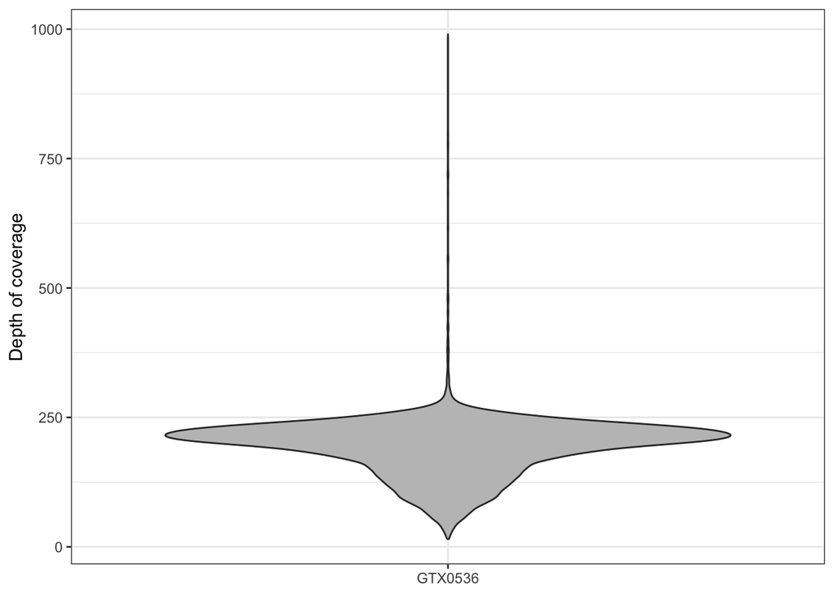

```r
vcf <- read.vcfR("../analysis_and_temp_files/04_SNP/GTX0536_nuclear_final_sort2-miss1.reformat.noTEs.vcf", verbose = FALSE)

# Get the total coverage of the site
coverage <- extract.gt(vcf, element="Cov", as.numeric = TRUE) %>% data.frame() %>% tibble::rownames_to_column("POS") %>% gather("sample", "cov", -POS)
# Get depth of the first allele
reads1 <- extract.gt(vcf, element="Reads1", as.numeric = TRUE) %>% data.frame() %>% tibble::rownames_to_column("POS") %>% gather("sample", "allele1", -POS)
reads2 <- extract.gt(vcf, element="Reads2", as.numeric = TRUE) %>% data.frame() %>% tibble::rownames_to_column("POS") %>% gather("sample", "allele2", -POS)


vcfdf <- cbind(coverage, allele1 = reads1$allele1, allele2 = reads2$allele2) %>% filter((allele1 + allele2) == cov)

## Calculate the Minor Allele Frequency per site and remove homozygous sites
vcfdf <- mutate(vcfdf, maf = pmin(allele1, allele2)/cov) %>% filter(maf > 0) %>%
  mutate(vcfdf, major = pmax(allele1, allele2)/cov)

ggplot(vcfdf %>% filter(cov < 1000), aes(x=sample, y=cov)) +
  geom_violin(fill="#C0C0C0", adjust=1.0, scale = "count", trim=TRUE) +
  theme_bw() + ylab("Depth of coverage") +
  theme(axis.title.x = element_blank())
```

- This looks very haploid

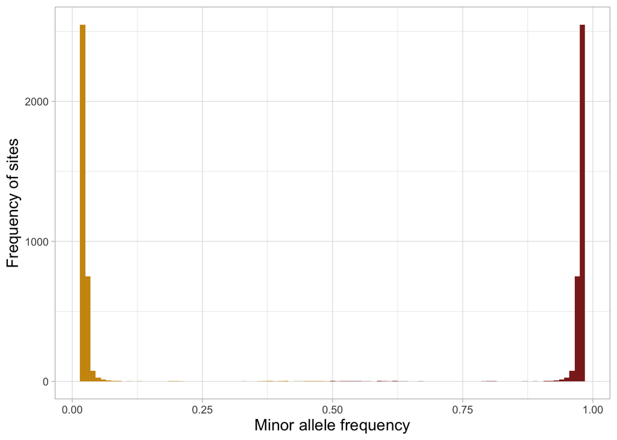

```r
vcfdf2<- vcfdf %>% filter(cov < 240, cov > 200, maf>0.02,major<0.98)
ggplot(vcfdf2) +
   geom_histogram(aes(x = maf),fill = "darkgoldenrod3",binwidth=0.01) + ylab("Count") +
  geom_histogram(aes(x = major),fill = "#8c2720",binwidth=0.01)+
   xlab("Minor allele frequency") + ylab("Frequency of sites") +
  theme_light() +

  theme(strip.text.x = element_text(size = 13),
        axis.title=element_text(size=13)) +
  guides(fill=FALSE) # Remove legend
```

- Zooming into the plot, however, can see a peak aroung 40-60%. The peak looks broad, not sure if it’s okay

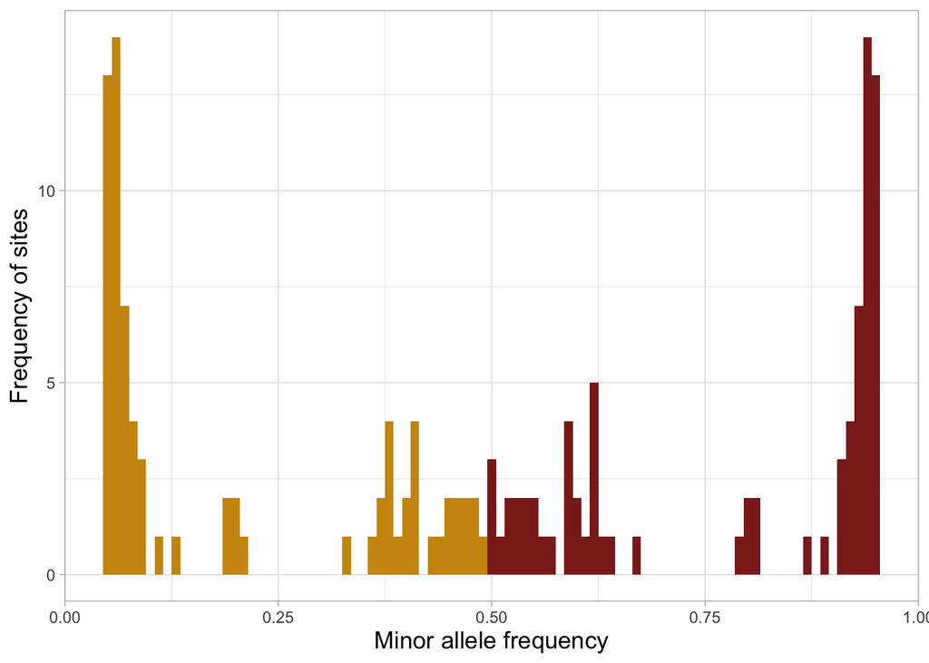

```r
vcfdf2<- vcfdf %>% filter(cov < 240, cov > 200, maf>0.05,major<0.95)
ggplot(vcfdf2) +
   geom_histogram(aes(x = maf),fill = "darkgoldenrod3",binwidth=0.01) + ylab("Count") +
  geom_histogram(aes(x = major),fill = "#8c2720",binwidth=0.01)+
   xlab("Minor allele frequency") + ylab("Frequency of sites") +
  theme_light() +

  theme(strip.text.x = element_text(size = 13),
        axis.title=element_text(size=13)) +
  guides(fill=FALSE) # Remove legend
```

- The peak 40-60% comes almost exclusively from one contig, and more specifically from a 7 kbp stretch GTX0536_10:112447-119090
  - Looking more closely, these are two regions flanking a gene model: 112447-115459 (has 36-41% maf) and 117766-119090 (39-50%)

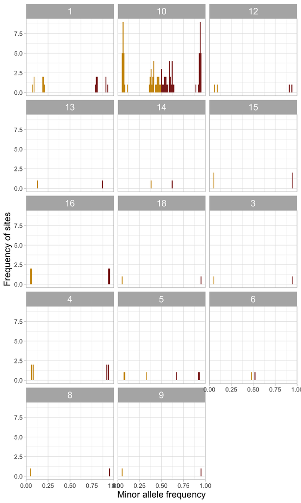

```r
vcfdf$contig<-str_replace(vcfdf$POS,"GTX0536_","")
vcfdf$contig<- sub("\\_.*", "", vcfdf$contig)
vcfdf$position<- sub("GTX0536\\_[0-9]+\\_", "", vcfdf$POS) %>% as.numeric()

ggplot(vcfdf %>% filter(cov < 240, cov > 200, maf>0.05,major<0.95)) +
   geom_histogram(aes(x = maf),fill = "darkgoldenrod3",binwidth=0.01) + ylab("Count") +
  geom_histogram(aes(x = major),fill = "#8c2720",binwidth=0.01)+
   xlab("Minor allele frequency") + ylab("Frequency of sites") +
  theme_light() +
  theme(strip.text.x = element_text(size = 13),
        axis.title=element_text(size=13)) +
  guides(fill=FALSE) +# Remove legend
facet_wrap(~contig,ncol=3)
```

- Blasted these regions against the rest of the assembly

```r
samtools faidx analysis_and_temp_files/02_genome_annotation/GTX0536_nuclear_final_sort2.fasta GTX0536_10:112447-115459 > analysis_and_temp_files/04_SNP/GTX0536_10_high_maf.fa

samtools faidx analysis_and_temp_files/02_genome_annotation/GTX0536_nuclear_final_sort2.fasta GTX0536_10:117766-119090 >> analysis_and_temp_files/04_SNP/GTX0536_10_high_maf.fa

blastn -query analysis_and_temp_files/04_SNP/GTX0536_10_high_maf.fa -subject analysis_and_temp_files/02_genome_annotation/GTX0536_nuclear_final_sort2.fasta -outfmt 6 -out analysis_and_temp_files/02_genome_annotation/GTX0536_nuclear_final_sort2.blast
```

- The stretches received 483 and 283 hits respectively, all hits were >80% identical and many covered >70% of the query. They also came from many different contigs. From this, I can conclude that these two regions are in fact repeats that somehow evaded annotation
- Removed the SNPs from this region

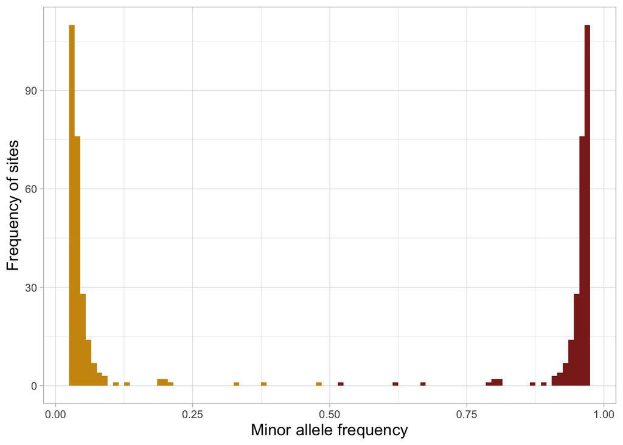

```r
vcfdf2<- vcfdf %>% filter(cov < 240, cov > 200, maf>0.03,major<0.97) %>%
  filter(contig!=10 | position<112447 | position>119090)
ggplot(vcfdf2) +
   geom_histogram(aes(x = maf),fill = "darkgoldenrod3",binwidth=0.01) + ylab("Count") +
  geom_histogram(aes(x = major),fill = "#8c2720",binwidth=0.01)+
   xlab("Minor allele frequency") + ylab("Frequency of sites") +
  theme_light() +

  theme(strip.text.x = element_text(size = 13),
        axis.title=element_text(size=13)) +
  guides(fill=FALSE) # Remove legend
```

```r
ggsave("../results/maf.pdf",width=3,height=2)
```

#### nQuire

- Compile

```r
cd ../nQuire
make submodules
make
```

- Run

```r
cd ../08_isolation_trebouxia
../nQuire/nQuire create -b analysis_and_temp_files/04_SNP/clair_in/GTX0536_nuclear_final_sort.bam -o analysis_and_temp_files/04_SNP/GTX0536_nQuire

../nQuire/nQuire view  analysis_and_temp_files/04_SNP/clair_in/GTX0536_nQuire.bin > analysis_and_temp_files/04_SNP/GTX0536_nQuire.txt
```

- Visualize

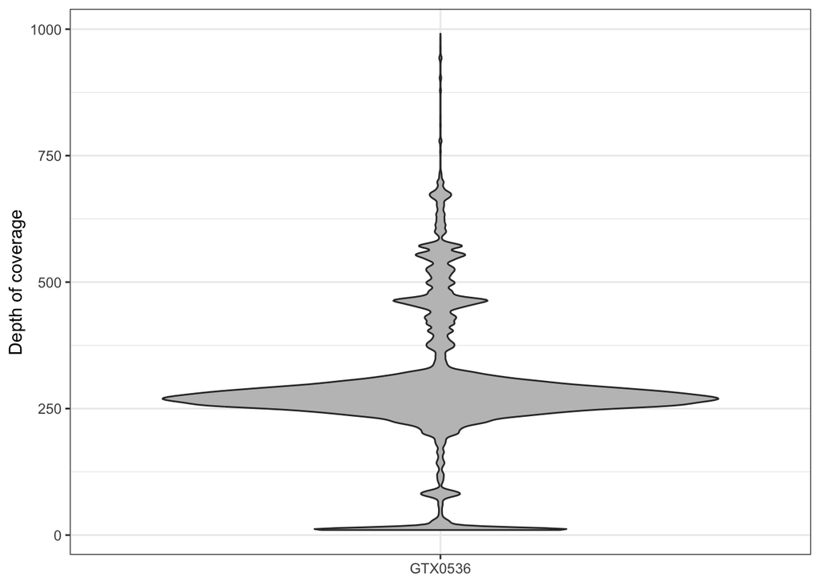

```r
nq <- read.delim2("../analysis_and_temp_files/04_SNP/GTX0536_nQuire.txt",header=F)
colnames(nq)<-c("cov","allele1", "allele2")
## Calculate the Minor Allele Frequency per site and remove homozygous sites
nq <- mutate(nq, maf = pmin(allele1, allele2)/cov) %>% filter(maf > 0)

ggplot(nq%>% filter(cov < 1000), aes(x="GTX0536", y=cov)) +
  geom_violin(fill="#C0C0C0", adjust=1.0, scale = "count", trim=TRUE) +
  theme_bw() + ylab("Depth of coverage") +
  theme(axis.title.x = element_blank())
```

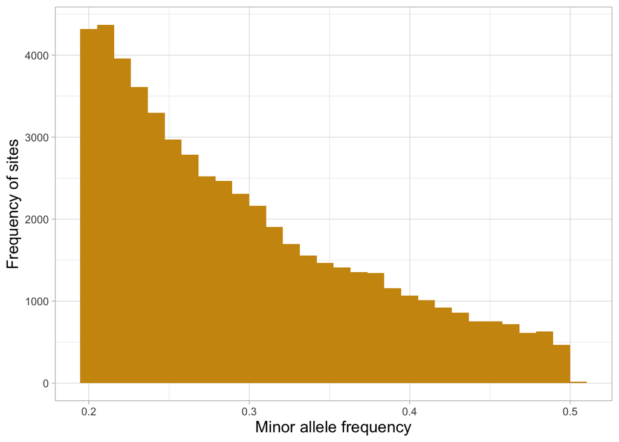

```r
nq2<- nq %>% filter(cov < 300, cov > 150)
ggplot(nq2, aes(x = maf, fill = sample)) +
   geom_histogram(fill = "darkgoldenrod3") + ylab("Count") +  ## Plot the raw counts
   xlab("Minor allele frequency") + ylab("Frequency of sites") +
  theme_light() +

  theme(strip.text.x = element_text(size = 13),
        axis.title=element_text(size=13)) +
  guides(fill=FALSE) # Remove legend
```

### 6.2 RNA data

- Align RNA with STAR

```r
mkdir analysis_and_temp_files/04_SNP/GTX0536_STAR_index -p

source package /tgac/software/testing/bin/STAR-2.5.4b
source package /tgac/software/testing/bin/gcc-4.9.1
source package aeee87c4-1923-4732-aca2-f2aff23580cc

STAR --runThreadN 10  --genomeSAindexNbases 6 \
--runMode genomeGenerate \
--genomeDir analysis_and_temp_files/04_SNP/GTX0536_STAR_index \
--genomeFastaFiles analysis_and_temp_files/02_genome_annotation/GTX0536_nuclear_final_sort.fasta

sbatch --mem=210G -c 20 --wrap="code/star_align.sh  \
data/RNA_seq/X204SC25014007-Z01-F001/01.RawData/GTX0532/GTX0532_EKRN250006470-1A_22MTC7LT4_L8_1.fq.gz \
data/RNA_seq/X204SC25014007-Z01-F001/01.RawData/GTX0532/GTX0532_EKRN250006470-1A_22MTC7LT4_L8_2.fq.gz \
analysis_and_temp_files/04_SNP/GTX0536_STAR_index/touch 20 analysis_and_temp_files/04_SNP/GTX0536_GTX0532.bam"
```

- Sort the bam file

```r
samtools index analysis_and_temp_files/04_SNP/GTX0536_GTX0532Aligned.sortedByCoord.out.bam
```

- Deduplicate with picard 2.21.2

```r
source package ce4daee0-abd9-4cc6-8b13-5fe8ede3b149

picard MarkDuplicates I=analysis_and_temp_files/04_SNP/GTX0536_GTX0532Aligned.sortedByCoord.out.bam O=analysis_and_temp_files/04_SNP/GTX0536_GTX0532Aligned.sortedByCoord.dedup.bam M=analysis_and_temp_files/04_SNP/GTX0536_GTX0532Aligned.sortedByCoord.dedup.stats.txt ASSUME_SORT_ORDER=coordinate CREATE_INDEX=true TMP_DIR="temp"
```

- Pileup

```r
source package 638df626-d658-40aa-80e5-14a275b7464b
source package /tsl/software/testing/bin/varscan-2.3.9

samtools mpileup -f analysis_and_temp_files/02_genome_annotation/GTX0536_nuclear_final_sort.fasta analysis_and_temp_files/04_SNP/GTX0536_GTX0532Aligned.sortedByCoord.dedup.bam | varscan mpileup2snp --p-value 0.1 --min-var-freq 0.005 | bgzip > analysis_and_temp_files/04_SNP/GTX0536_GTX0532.vcf.gz
```

- Output:
  - 67461432 bases in pileup file
  - 18168 variant positions (16781 SNP, 1387 indel)
  - 576 were failed by the strand-filter
  - 16230 variant positions reported (16230 SNP, 0 indel)
- Filtering out steps with missing data

```r
zless analysis_and_temp_files/04_SNP/GTX0536_GTX0532.vcf.gz | grep -v ':-:-:-:-' | bgzip > analysis_and_temp_files/04_SNP/GTX0536_GTX0532-miss1.vcf.gz
```

- Reformat the output from varscan (replace whitespaces with tabs)

```r
source package 6dc9949e-7282-4b10-b6f4-7fed2a08821e

/software/6dc9949e-7282-4b10-b6f4-7fed2a08821e/bin/python3 code/filter_vcf.py analysis_and_temp_files/04_SNP/GTX0536_GTX0532-miss1.vcf.gz analysis_and_temp_files/02_genome_annotation/GTX0536_nuclear_final_sort.fasta analysis_and_temp_files/04_SNP/GTX0536_GTX0532-miss1.reformat.vcf 100000
```

- This looks haploid to me! However, it’s not clear whether you can use RNA data to detect diploidy

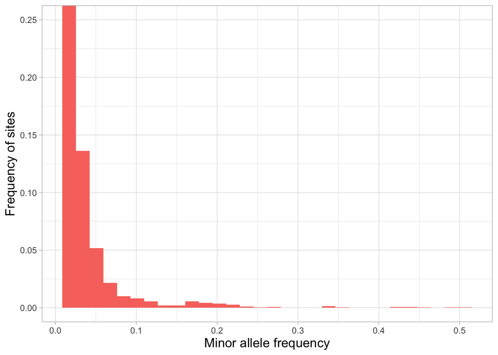

```r
vcf <- read.vcfR("../analysis_and_temp_files/04_SNP/GTX0536_GTX0532-miss1.reformat.vcf", verbose = FALSE)

# Get the total coverage of the site
coverage <- extract.gt(vcf, element="Cov", as.numeric = TRUE) %>% data.frame() %>% tibble::rownames_to_column("POS") %>% gather("sample", "cov", -POS)
# Get depth of the first allele
reads1 <- extract.gt(vcf, element="Reads1", as.numeric = TRUE) %>% data.frame() %>% tibble::rownames_to_column("POS") %>% gather("sample", "allele1", -POS)
reads2 <- extract.gt(vcf, element="Reads2", as.numeric = TRUE) %>% data.frame() %>% tibble::rownames_to_column("POS") %>% gather("sample", "allele2", -POS)


vcfdf <- cbind(coverage, allele1 = reads1$allele1, allele2 = reads2$allele2)

## Calculate the Minor Allele Frequency per site and remove homozygous sites
vcfdf <- mutate(vcfdf, maf = pmin(allele1, allele2)/cov) %>% filter(maf > 0)

ggplot(vcfdf %>% filter(maf>0.01), aes(x = maf, fill = sample)) +
  # geom_histogram(fill = "darkgoldenrod3") + ylab("Count") +  ## Plot the raw counts
  geom_histogram(aes(y=(..count..)/tapply(..count..,..PANEL..,sum)[..PANEL..])) +
   xlab("Minor allele frequency") + ylab("Frequency of sites") +
  theme_light() +
  coord_cartesian(ylim=c(0, 0.25)) + # Remove the loooong values to improve clarity
  #scale_fill_manual(values = c("L.columbiana" = "#ecbdecff",
   #                            "L.lupina" = "#c7e1a8ff",
    #                           "L.lupina_culture" = "#c7e1a8ff",
     #                          "L.rugosa" = "#f9d5bdff",
      #                         "L.vulpina" = "#b7d2fdff")) +
  theme(strip.text.x = element_text(size = 13),
        axis.title=element_text(size=13)) +
  guides(fill=FALSE) # Remove legend
```